# Investigating Missing Data using `groupby()`

## Aim

To investigate **missing data patterns** using the `groupby()` function and determine whether missing values appear to be **related to other observed variables**.

## What Will We Investigate?

In this lab, we will use `groupby()` to answer questions such as:

- Which **gender** has the highest percentage of missing `Family_Income`?
- Which **department** has the most missing values?
- Does the missingness appear **random or related to another variable**?
- Can this dataset be considered an example of **MAR (Missing At Random)**?

### Key Idea

> This is where `groupby()` stops being just a programming function and becomes a **statistical investigation tool** for understanding missing data.

# Key Data Science Question

Now we can answer a real data science question:

> **"Is the missing data random, or does it follow a pattern?"**

```python
# Step 1 – Import Pandas
import pandas as pd
```

```python
# Step 2 – Load Dataset
df = pd.read_csv("groupby_students.csv")
```

```python
# Step 3 – Display Dataset
df.head()
```

|  | Student_ID | Gender | Department | Semester | Attendance | Family_Income | CGPA | Scholarship | Hosteller | Placement_Package |
| --- | --- | --- | --- | --- | --- | --- | --- | --- | --- | --- |
| 0 | S001 | Male | BCA | 1 | 77 | 380000.0 | 7.01 | No | Yes | NaN |
| 1 | S002 | Female | BCA | 5 | 87 | NaN | 6.30 | No | Yes | NaN |
| 2 | S003 | Male | MBA | 1 | 88 | 450000.0 | 8.14 | No | Yes | NaN |
| 3 | S004 | Female | BBA | 3 | 69 | NaN | 6.91 | No | No | NaN |
| 4 | S005 | Male | BCA | 3 | 82 | 830000.0 | 8.19 | No | Yes | NaN |

```python
# Step 4 – Check Missing Values
df.isnull().sum()
```

```
Student_ID             0
Gender                 0
Department             0
Semester               0
Attendance             0
Family_Income         50
CGPA                   0
Scholarship            0
Hosteller              0
Placement_Package    144
dtype: int64
```

```python
# Activity 1 – Count Missing Income Values
df["Family_Income"].isnull().sum()
```

```
np.int64(50)
```

```python
# Activity 2 – Missing Income by Gender
df.groupby("Gender")["Family_Income"].apply(
    lambda x: x.isnull().sum()
)
```

```
Gender
Female    40
Male      10
Name: Family_Income, dtype: int64
```

## Is the Missing Data Equally Distributed?

**No.**

Most missing values belong to **Female students**.

This suggests that the **missingness depends on Gender**.

### Possible Conclusion

> The dataset may exhibit a **MAR (Missing At Random)** pattern.

```python
df.groupby("Gender")["Family_Income"].apply(
    lambda x: x.isnull().mean()*100
)
```

```
Gender
Female    40.0
Male      10.0
Name: Family_Income, dtype: float64
```

# Can We Conclude That This Is MAR?

**No.**

This is one of the most important lessons in missing-data analysis.

From this result, we can only say:

> **The missingness appears to be associated with Gender, an observed variable.**

This provides **evidence consistent with MAR**, but it does **not prove** that the missing-data mechanism is MAR.

## Why Can't We Prove MAR?

Because we do not know **why** the values are missing.

For example, possible reasons include:

- Female students may have skipped the question more often.
- A data-entry operator may have missed more records for female students.
- There could have been an issue with one survey form.
- The data collection process may have differed between groups.

The dataset shows **what happened**, but not **why it happened**.

# Discussion

> **Is the missing data completely random?**

**Expected answer:**

**Probably not.**

> **Why do you think so?**

**Expected answer:**

Because the percentage of missing values is much higher for Female students than for Male students.

Ask:

> **Which observed variable seems related to the missing values?**

**Expected answer:**

**Gender**

> **Can we prove that the missing-data mechanism is MAR?**

**Expected answer:**

**No.**

We can only say that the observed pattern is **consistent with MAR**.

# Real Data Scientist's Thinking

A data scientist would write something like:

> "The proportion of missing `Family_Income` values is substantially higher among female students (40%) than male students (10%). This indicates that missingness may be associated with the observed variable `Gender`. Further investigation and domain knowledge are required before concluding that the missing-data mechanism is MAR."

Notice the careful wording:

- **"may be associated"**
- **"indicates"**
- **"further investigation"**
- **"cannot conclude"**

This is how statistical conclusions should be written.

# Before Activity 5

one final question:

> **If Gender influences whether `Family_Income` is missing, should we ignore Gender while filling the missing values?**

This naturally leads to the next discussion on **imputation strategies**, where students will learn that related variables often need to be considered when handling missing data.

This question prepares them to think beyond simply replacing missing values with a single overall mean.

# Activity 5 – Investigating Missing Data by Department

## Objective

To determine whether the missing values in `Family_Income` are related to the **Department**.

```python
df.groupby("Department")["Family_Income"].apply(
    lambda x: x.isnull().sum()
)
```

```
Department
BBA     9
BCA    12
MBA    18
MCA    11
Name: Family_Income, dtype: int64
```

# Activity 6 – Calculate Missing Percentage

Instead of simply counting missing values, calculate the **percentage of missing values**.

This gives us a fair comparison between groups, even when the groups contain different numbers of students.

```python
df.groupby("Department")["Family_Income"].apply(
    lambda x: x.isnull().mean() * 100
)
```

```
Department
BBA    20.930233
BCA    26.666667
MBA    31.578947
MCA    20.000000
Name: Family_Income, dtype: float64
```

# Data Scientist's Interpretation

A professional report might state:

> "The proportion of missing `Family_Income` varies across departments. This suggests that missingness may be associated with the `Department` variable. However, further investigation and domain knowledge are required before drawing conclusions about the underlying missing-data mechanism."

# Think Like a Data Scientist

At this point, you have investigated:

- ✅ **Gender**
- ✅ **Department**

The next logical question is:

> **"What if missingness depends on both Gender and Department together?"**

For example:

- Female students in **MCA** may have a higher percentage of missing income than female students in **BCA**.

This introduces **two-variable (bivariate) analysis**, and it is where:

```
groupby(["Gender", "Department"])
```

# Data Scientist's Interpretation

A professional report might state:

> "The proportion of missing `Family_Income` varies across departments. This suggests that missingness may be associated with the `Department` variable. However, further investigation and domain knowledge are required before drawing conclusions about the underlying missing-data mechanism."

# Think Like a Data Scientist

At this point, you have investigated:

- ✅ **Gender**
- ✅ **Department**

The next logical question is:

> **"What if missingness depends on both Gender and Department together?"**

For example:

- Female students in **MCA** may have a higher percentage of missing income than female students in **BCA**.

This introduces **two-variable (bivariate) analysis**, and it is where:

```
groupby(["Gender", "Department"])
```

```python
df.groupby(["Department", "Gender"])["Family_Income"].apply(
    lambda x: x.isnull().mean() * 100
)
```

```
Department  Gender
BBA         Female    42.105263
            Male       4.166667
BCA         Female    52.173913
            Male       0.000000
MBA         Female    40.625000
            Male      20.000000
MCA         Female    26.923077
            Male      13.793103
Name: Family_Income, dtype: float64
```

# From Missing Data to Machine Learning

```
Collect Data
      │
      ▼
Missing Values
      │
      ▼
Univariate Analysis
      │
      ▼
Bivariate Analysis
      │
      ▼
Multivariate Analysis
      │
      ▼
Data Cleaning
      │
      ▼
Feature Engineering
      │
      ▼
Machine Learning
```

# Now Comes the Most Interesting Question

After examining **Gender** and **Department** together, ask your students:

> **What if the missing values are not associated with Gender or Department individually, but with their combination—or even several variables at once?**

This is exactly how a **data scientist** thinks.

They don't stop after investigating one variable. Instead, they continue asking deeper questions:

- Is missingness related to **Gender**?
- Is it related to **Department**?
- Is it related to **Semester**?
- Does it depend on **Gender and Department together**?
- Does it depend on several variables simultaneously?

As we investigate more variables, we move from **Univariate Analysis** to **Bivariate Analysis** and eventually to **Multivariate Analysis**.

# The Next Big Idea

At this stage, data scientists make an important shift in thinking.

Instead of asking:

> **"What is the Family Income?"**

they ask:

> **"Why is the Family Income missing?"**

Now the focus is no longer on the income itself.

The focus is on the **missingness**.

This naturally leads to the next topic.

# Activity 9 – Creating a Missing Indicator (`Income_Missing`)

One of the most powerful techniques used by professional data scientists is creating a **Missing Indicator**.

Instead of treating missing values as a problem, we transform them into a **new feature**.

For example:

| Family_Income | Income_Missing |
| --- | --- |
| 550000 | False |
| NaN | True |
| 420000 | False |
| NaN | True |
| 680000 | False |

Here,

- `True` means the value is missing.
- `False` means the value is available.

This new feature can now be analyzed just like any other variable.

We can ask questions such as:

- Which gender has the highest percentage of missing income?
- Which department has the highest missing rate?
- Which semester has the most missing values?
- Is missingness related to scholarship status?

The exciting part is that **missingness itself becomes valuable information**.

> **Sometimes, the fact that a value is missing is more informative than the value itself.**

This is often an **"aha!" moment** for you because they realize that missing data is not always something to remove—it can also become a useful feature for analysis and machine learning.

```python
df["Income_Missing"] = df["Family_Income"].isnull()
```

```python
df
```

|  | Student_ID | Gender | Department | Semester | Attendance | Family_Income | CGPA | Scholarship | Hosteller | Placement_Package | Income_Missing |
| --- | --- | --- | --- | --- | --- | --- | --- | --- | --- | --- | --- |
| 0 | S001 | Male | BCA | 1 | 77 | 380000.0 | 7.01 | No | Yes | NaN | False |
| 1 | S002 | Female | BCA | 5 | 87 | NaN | 6.30 | No | Yes | NaN | True |
| 2 | S003 | Male | MBA | 1 | 88 | 450000.0 | 8.14 | No | Yes | NaN | False |
| 3 | S004 | Female | BBA | 3 | 69 | NaN | 6.91 | No | No | NaN | True |
| 4 | S005 | Male | BCA | 3 | 82 | 830000.0 | 8.19 | No | Yes | NaN | False |
| ... | ... | ... | ... | ... | ... | ... | ... | ... | ... | ... | ... |
| 195 | S196 | Female | MBA | 1 | 94 | NaN | 6.99 | No | No | NaN | True |
| 196 | S197 | Male | MBA | 3 | 78 | 450000.0 | 8.77 | Yes | No | NaN | False |
| 197 | S198 | Female | MCA | 3 | 63 | 950000.0 | 8.32 | Yes | No | NaN | False |
| 198 | S199 | Male | BCA | 3 | 65 | 820000.0 | 8.72 | Yes | No | NaN | False |
| 199 | S200 | Female | MCA | 3 | 65 | 820000.0 | 9.32 | Yes | Yes | NaN | False |

200 rows × 11 columns

```python
print(df[["Family_Income", "Income_Missing"]])
```

```
     Family_Income  Income_Missing
0         380000.0           False
1              NaN            True
2         450000.0           False
3              NaN            True
4         830000.0           False
..             ...             ...
195            NaN            True
196       450000.0           False
197       950000.0           False
198       820000.0           False
199       820000.0           False

[200 rows x 2 columns]
```

## Analyze Missingness by Gender

Now we can use the `groupby()` concept that we just learned.

```
df.groupby("Gender")["Income_Missing"].mean()
```

```python
df.groupby("Gender")["Income_Missing"].mean()
```

```
Gender
Female    0.4
Male      0.1
Name: Income_Missing, dtype: float64
```

```python
df.groupby("Gender")["Income_Missing"].mean() * 100
```

```
Gender
Female    40.0
Male      10.0
Name: Income_Missing, dtype: float64
```

## Analyze Missingness by Department

Now we can use the `groupby()` concept that we just learned.

```
df.groupby("Department")["Income_Missing"].mean()
```

```python
df.groupby("Department")["Income_Missing"].mean() * 100
```

```
Department
BBA    20.930233
BCA    26.666667
MBA    31.578947
MCA    20.000000
Name: Income_Missing, dtype: float64
```

# Analyze Missingness by Semester

```
df.groupby("Semester")["Income_Missing"].mean() * 100
```

```python
df.groupby("Semester")["Income_Missing"].mean() * 100
```

```
Semester
1    27.536232
3    23.880597
5    23.437500
Name: Income_Missing, dtype: float64
```

```python
# Analyze Missingness by Scholarship Status
df.groupby("Scholarship")["Income_Missing"].mean() * 100
```

```
Scholarship
No     25.233645
Yes    24.731183
Name: Income_Missing, dtype: float64
```

### Key Notes

1. A **missing indicator** converts missingness into a new feature.
2. `True` means the value is missing; `False` means it is available.
3. Boolean values behave like `1` and `0` when calculating the mean.
4. Therefore, `mean() × 100` gives the **missing percentage**.
5. `groupby()` helps us discover **which groups have higher missingness**.
6. Missingness itself may contain useful information.
7. We should **investigate the pattern before deleting missing records**.
8. In machine learning, the missing indicator can sometimes be retained as a useful feature.
9. **Missing indicator ≠ imputation**. The indicator tells us *whether* the value was missing; imputation decides *what value to put in its place*.

**The key conceptual transition is:**

`NaN → True/False → Pattern → Information → Feature`

That is exactly why **Missing Indicator** is an important Feature Engineering technique.

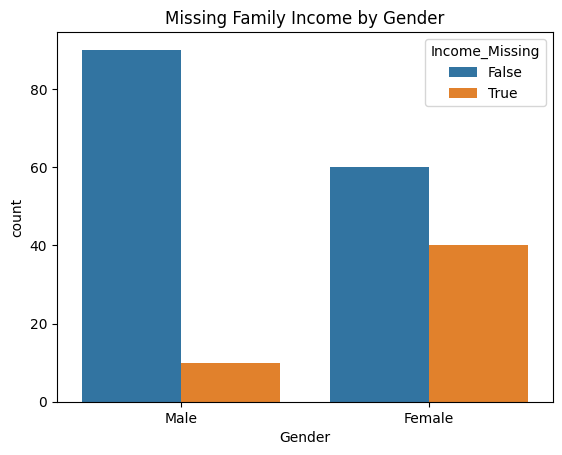

```python
import seaborn as sns
import matplotlib.pyplot as plt

sns.countplot(data=df, x="Gender", hue="Income_Missing")

plt.title("Missing Family Income by Gender")
plt.show()
```